# Final Project: Data Join

Author

Naman Mutalik Desai and Rithin Karthik

Published

November 16, 2026

## Part 1: Find Data

Data Source: Provide a weblink or appropriate reference to the data set. What is the source, and who collected the data? Why is the source reliable? Demonstrate that it is a real data set.

Web Links:

https://www.tandfonline.com/doi/full/10.1080/07448481.2021.1927049#d1e942

https://www.kaggle.com/datasets/arshadrahmanziban/social-media-aspects

First Dataset:

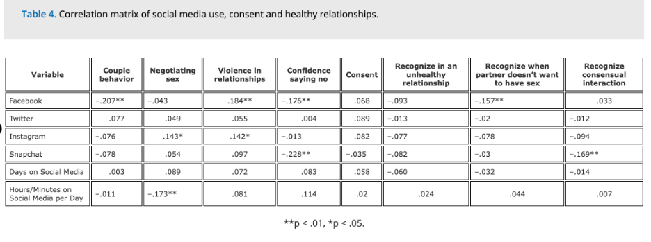

Data Meaning: What does the data represent? How is the information it contains relevant to the content of your first data set?

- The second dataset is a survey that asks social media users across platforms how their activity has affected real life relationships. It allows us to see if there’s a relationship between the ability of users to perceive healthy relationships (in our first dataset), social media usage, and real-life relationship health.

Data Join: What features (i.e., date, country, university, zip code) do you intend to join to your data? Are there any features that you would need to change to ensure your join is successful (e.g., consider how to join “United States of America” from one data set with “USA” or “US” in another)?

- Social Media Platform will be our join key so we can run a group_by by social media platforms and summarize key statistics like average time spent, relationship impact, and ability to perceive healthy relationships. The second dataset only has information on Facebook and Instagram users, so we have to trim the information on other social media platforms in the first dataset. We also have to quantify ranges of hours spent on social media by taking the average of the ranges (i.e. 3-5 hours becomes 4 hours). We also have to turn answers like “Improved”, “Worsened”, and “No Change” into quantifiable numbers like 1, -1, and 0 so that an average can be taken.

Data Issues: Are there any missing, implausible values, or other data quality issues in the relevant variables? How many? Does this impact the reliability of the data source?

Data Observations: Demonstrated in Part 2 below.

## Part 2: Data Join

```r
library(tidyverse)
social_df <- read_csv("dataset.csv")
relationships_df <- read_csv("Recognizing Healthy Relationships.csv")
#filtered out platforms not Facebook or Instagram for simplicity
joined <- inner_join(
  social_df,
  relationships_df,
  by = c("Which social media platforms do you use the most?" = "Variable")
)

#42 rows and 18 columns as shown by the functions below
colnames(joined)
```

```
 [1] "What is your age group?"
 [2] "What is your occupation?"
 [3] "Where do you live?"
 [4] "How many hours per day do you spend on social media?"
 [5] "How has social media affected your real-life relationships?"
 [6] "How frequently do you use email for communication?"
 [7] "Do you use LinkedIn for professional networking?"
 [8] "How often do you use WhatsApp for communication?"
 [9] "Which social media platforms do you use the most?"
[10] "Do you feel that social media affects your mental health?"
[11] "Couple behavior"
[12] "Negotiating sex"
[13] "Violence in relationships"
[14] "Confidence saying no"
[15] "Consent"
[16] "Recognize in an unhealthy relationship"
[17] "Recognize when partner doesn‚Äôt want to have sex"
[18] "Recognize consensual interaction"
```

```r
nrow(joined)
```

```
[1] 42
```

```r
glimpse(joined)
```

```
Rows: 42
Columns: 18
$ `What is your age group?`                                     <chr> "18-25",…
$ `What is your occupation?`                                    <chr> "Student…
$ `Where do you live?`                                          <chr> "Urban A…
$ `How many hours per day do you spend on social media?`        <chr> "3-5 hou…
$ `How has social media affected your real-life relationships?` <chr> "No Chan…
$ `How frequently do you use email for communication?`          <chr> "Rarely"…
$ `Do you use LinkedIn for professional networking?`            <chr> "Rarely"…
$ `How often do you use WhatsApp for communication?`            <chr> "Daily",…
$ `Which social media platforms do you use the most?`           <chr> "Faceboo…
$ `Do you feel that social media affects your mental health?`   <chr> "Not sur…
$ `Couple behavior`                                             <dbl> -0.207, …
$ `Negotiating sex`                                             <dbl> -0.043, …
$ `Violence in relationships`                                   <dbl> 0.184, 0…
$ `Confidence saying no`                                        <dbl> -0.176, …
$ Consent                                                       <dbl> 0.068, 0…
$ `Recognize in an unhealthy relationship`                      <dbl> -0.093, …
$ `Recognize when partner doesn‚Äôt want to have sex`           <dbl> -0.157, …
$ `Recognize consensual interaction`                            <dbl> 0.033, 0…
```

## Part 3: Data Documentation

The above linked articles and sources explain the data columns and what they mean. The most relevant variables we will use are social media platform, daily usage, and the metrics on identifying healthy relationships from dataset 1.

8 Human Rights Principles:  
privacy, accountability, safety and security, transparency and explainability, fairness and non-discrimination, human control of technology, professional responsibility, and promotion of human values.

## Part 4: Data Wrangling

We wanted to quantify whether someone’s relationships got better or worse because of social media, and this lets us compare and summarize statistics

```r
joined <- joined |>
  mutate(
    `How has social media affected your real-life relationships?` = case_match
    (
      `How has social media affected your real-life relationships?`,
      "Worsened" ~ -1,
      "No Change" ~ 0,
      "Improved" ~ 1
    )
  )
```

We wanted to also make this column numerical, so we changed the values from ranges to the average of those ranges to create a column that can be operated on.

```r
joined <- joined |>
  mutate(
    `How many hours per day do you spend on social media?` = case_match(
      `How many hours per day do you spend on social media?`,
      "1-2 hours" ~ 1.5,
      "3-5 hours" ~ 4,
      "More than 5 hours" ~ 6
    )
  )
```

We wanted to get statistics on the columns we mutated by platform, so we calculated the averages for each of them and made a summary dataframe.

```r
# Create summary dataframe grouped by platform
summary_df <- joined %>%
  group_by(`Which social media platforms do you use the most?`) %>%
  summarize(
    total_respondents = n(),
    avg_relationship_effect = mean(`How has social media affected your real-life relationships?`, na.rm = TRUE),
    avg_daily_hours = mean(`How many hours per day do you spend on social media?`, na.rm = TRUE),
    violence_in_relationships_coef = first(`Violence in relationships`),
    recognize_unhealthy_rel_coef = first(`Recognize in an unhealthy relationship`)
  )

summary_df
```

```
# A tibble: 2 × 6
  Which social media platforms do you…¹ total_respondents avg_relationship_eff…²
  <chr>                                             <int>                  <dbl>
1 Facebook                                             36                 -0.111
2 Instagram                                             6                  0
# ℹ abbreviated names: ¹`Which social media platforms do you use the most?`,
#   ²avg_relationship_effect
# ℹ 3 more variables: avg_daily_hours <dbl>,
#   violence_in_relationships_coef <dbl>, recognize_unhealthy_rel_coef <dbl>
```

## Part 5: Providing Group Information

Topic of Interest: How has social media usage affected college students’ perceptions of healthy relationships and their ability to identify abuse?

TA: Tiffany Guan

Lab Section: AB

Time: Tuesday, 11:30-12:20

Group Member 1: Rithin Karthik, iSchool Freshman, rithink@uw.edu.

Rithin is interested in the data processing that maps societal trends in behavior and perceptions.

Group Member 2: Naman Mutalik Desai, iSchool Freshman, namanmd@uw.edu.

Naman is interested in factors that shift human behavior and wants to learn how they are quantified and mapped.

Coding Notes:

We used Excel to reformat data tables so they could be cleaned up more easily in R. Otherwise, we relied on the knowledge and information taught in class.